# lab4

1)Символ Ω використовується для позначення нижньої межі часу виконання алгоритму або складності задачі. Це означає, що для будь-якого алгоритму, що вирішує певну задачу, час виконання не може бути меншим за певну функцію при достатньо великих вхідних даних.

2)$f(n)=n^3+7n^2-14n$ $g(n)=O(n^3)$ $O(g(n))=n^3$ $n^3+7n^2-14n<=cn^3$ $n^3+7n^2-14n<=n^3+7n^3-14n^3$ n0=1 c=6

3)

[figure not shown]

$g(n)=O(1.01^n)$

$1.01^n+n^{10}<=C*1.01^n$

$1.01^n+n^{10}<=n^{11}+1.01^n$

n0=1 C=1

4)

[figure not shown]

$g(n)=O(n^{1.3})$

$n^{1.3}+10log2n<=C*n^{1.3}$

$n^{1.3}+10log2n<=n^2+n^{1.3}$

n0=1 C=1

5)Ідея розпаралелювання обчислень  
Розпаралелювання обчислень полягає в тому, щоб виконувати незалежні підзадачі одночасно  
(на різних ядрах процесора або в різних потоках). Це дозволяє скоротити час виконання задачі.  
Для чого використовується розпаралелювання:  
1.Збільшення швидкості виконання складних обчислень.  
2.Використання можливостей багатоядерних процесорів.

Лінійний пошук легко розпаралелити, розділивши масив на частини та запустивши пошук паралельно.  
Бінарний пошук майже неможливо ефективно розпаралелити через послідовну залежність кожної ітерації від попередньої.  
Якщо ви працюєте з великими масивами, розпаралелювання лінійного пошуку може дати значне прискорення.  
Бінарний пошук і так досить швидкий, тому розпаралелювання зазвичай не потрібне.

6)Шляхи підвищення обчислювальної швидкості алгоритмів  
1.Оптимізація алгоритму 2.Розпаралелювання обчислень 3.Використання спеціалізованого обладнання  
4.Покращення коду 5.Зменшення обсягу вхідних даних 6.Зміна парадигми обчислень

[figure not shown]

# Завдання на самостійне опрацювання

**1. Оцінити асимптотичну складність алгоритму лінійного пошуку у О-нотації.**

### **Асимптотична складність лінійного пошуку**

Лінійний пошук — це простий алгоритм, у якому елемент шукається шляхом послідовної перевірки кожного елемента масиву.

### **Аналіз часу роботи лінійного пошуку**

1. **Найгірший випадок** — шуканий елемент або знаходиться в кінці масиву, або його немає зовсім. У цьому випадку потрібно перевірити всі ( n ) елементів масиву.
2. **Найкращий випадок** — елемент знаходиться на першій позиції, і ми завершуємо пошук за 1 ітерацію.
3. **Середній випадок** — припустимо, що елемент з рівною ймовірністю може знаходитися в будь-якій позиції. У середньому потрібно перевірити половину масиву, тобто ( n / 2 ) елементів.

### **Оцінка часу роботи лінійного пошуку**

| **Випадок** | **Кількість перевірок** | **Асимптотична складність** |
| --- | --- | --- |
| **Найгірший** | ( n ) | ( O(n) ) |
| **Середній** | ( n / 2 ) | ( O(n) ) (постійні коефіцієнти ігноруються) |
| **Найкращий** | 1 | ( O(1) ) |

### **Асимптотична складність**

- У загальному випадку, навіть якщо шуканий елемент знаходиться в середині масиву або ближче до кінця, доведеться переглядати більшу частину елементів.
- Таким чином, **найгірший випадок** визначає асимптотичну складність, яка дорівнює:  
  [ O(n) ] Це означає, що час виконання алгоритму зростає лінійно зі збільшенням розміру масиву ( n ).

**2.Оцінити асимптотичну складність алгоритму бінарного пошуку пошуку у О-нотації.**

### **Асимптотична складність бінарного пошуку**

Бінарний пошук — це ефективний алгоритм пошуку елементу в відсортованому масиві шляхом поділу масиву навпіл на кожній ітерації.

### **Аналіз роботи бінарного пошуку**

1. **Вхідні дані** — відсортований масив із ( n ) елементів.
2. **Алгоритм** — на кожній ітерації масив ділиться навпіл, і пошук триває лише в одній половині масиву.
3. **Кількість ітерацій** — на кожній ітерації розмір масиву зменшується від ( n ) до ( n/2 ), потім до ( n/4 ), ( n/8 ) і так далі.

### **Оцінка кількості ітерацій**

На кожному кроці розмір підмасиву зменшується вдвічі:  
[ $n, \frac{n}{2}, \frac{n}{4}, \frac{n}{8}, \dots, 1$ ] Кількість ітерацій ( k ) досягне 1, коли:  
[ $frac{n}{2^k} = 1$ ] Розв'яжемо це рівняння відносно ( k ):  
[ $n = 2^k \implies k = \log_2(n)$ ] Отже, для масиву розміру ( n ) потрібно зробити приблизно (  
$log_2(n)$ )ітерацій.

### **Асимптотична складність**

- У найгіршому випадку елемент буде знайдено лише на останній ітерації.
- Час виконання залежить від кількості ітерацій, яка дорівнює ( \log_2(n) ).
- Постійні множники та додаткові константи ігноруються в нотації ( O ).
- Отже, асимптотична складність бінарного пошуку:  
  [ O(\log n) ]

### **Часова складність бінарного пошуку**

| **Випадок** | **Кількість ітерацій** | **Асимптотична складність** |
| --- | --- | --- |
| **Найгірший** | ( \log_2(n) ) | ( O(\log n) ) |
| **Середній** | ( \log_2(n) ) | ( O(\log n) ) |
| **Найкращий** | 1 | ( O(1) ) |

### **Висновок**

- **Бінарний пошук** має складність ( O(\log n) ) у найгіршому та середньому випадках.
- У найкращому випадку елемент знаходиться з першої спроби, тому складність — ( O(1) ).
- Завдяки своїй ефективності бінарний пошук значно швидший за лінійний пошук для відсортованих масивів.

**3.Написати функцію, яка б могла повертати датафрейм з наступним складом полів: (“n”, “time”), де n – розмір масиву для функції `linear_searh();**

```python
import time
import pandas as pd
import random


def linear_search(a_list, x):
    i, length = 0, len(a_list)
    while i < length and x != a_list[i]:
        i += 1
    return i if i < length else -1


def linear_search_time(n_values):
    times = []
    for n in n_values:
        a_list = random.sample(range(1, 10*n), n)
        start_time = time.time()
        linear_search(a_list, -1)
        end_time = time.time()
        times.append(end_time - start_time)
    return pd.DataFrame({'n': n_values, 'time': times})

# Тестування функції
n_values = [600000, 700000, 900000, 1200000, 13000000]
linear_df = linear_search_time(n_values)
print(linear_df)
```

```
          n      time
0    600000  0.114928
1    700000  0.123924
2    900000  0.157902
3   1200000  0.220045
4  13000000  2.348974
```

**4.Написати функцію, яка б могла повертати датафрейм з наступним складом полів: (“n”, “time”), де n – розмір масиву для функції `bin_searh();**

```python
def bin_search(a_list, x, left, right):
    if left > right:
        return -1
    middle = (left + right) // 2
    if a_list[middle] == x:
        return middle
    elif a_list[middle] < x:
        return bin_search(a_list, x, middle + 1, right)
    else:
        return bin_search(a_list, x, left, middle - 1)


def bin_search_time(n_values):
    times = []
    for n in n_values:
        a_list = sorted(random.sample(range(1, 10*n), n))
        start_time = time.time()
        bin_search(a_list, -1, 0, len(a_list) - 1)
        end_time = time.time()
        times.append(end_time - start_time)
    return pd.DataFrame({'n': n_values, 'time': times})

# Тестування функції
bin_values = [600000, 700000, 900000, 1200000, 13000000]
bin_df = bin_search_time(bin_values)
print(bin_df)
```

```
          n  time
0    600000   0.0
1    700000   0.0
2    900000   0.0
3   1200000   0.0
4  13000000   0.0
```

**5.За результатами попередніх завдань побудувати графіки залежності часу виконання процедури пошуку від розміру масиву. Приклад побудови графіків у середовищі Ipython**

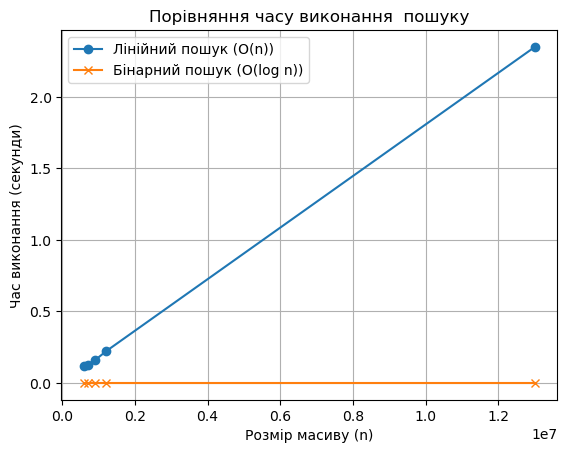

```python
import matplotlib.pyplot as plt

# графіки
def plot_time_comparison(linear_df, bin_df):
    plt.plot(linear_df['n'], linear_df['time'], label='Лінійний пошук (O(n))', marker='o')
    plt.plot(bin_df['n'], bin_df['time'], label='Бінарний пошук (O(log n))', marker='x')

    plt.xlabel('Розмір масиву (n)')
    plt.ylabel('Час виконання (секунди)')
    plt.title('Порівняння часу виконання  пошуку')
    plt.legend()
    plt.grid(True)
    plt.show()

#функції для графіка
plot_time_comparison(linear_df, bin_df)
```

**6.Оцінити, який з двох алгоритмів є більш ефективним та в якому діапазоні розміру задачі.**

### Оцінка ефективності алгоритмів лінійного та бінарного пошуку

#### 1. Асимптотична складність обох алгоритмів

- **Лінійний пошук (Linear Search)**:
  - **Складність**: (O(n)), де (n) — кількість елементів у масиві.
  - Алгоритм перевіряє кожен елемент масиву по черзі, поки не знайде шукане значення або не завершить перегляд всіх елементів.
- **Бінарний пошук (Binary Search)**:
  - **Складність**: (O(\log n)), де (n) — кількість елементів у масиві.
  - Алгоритм працює лише з відсортованими масивами. На кожному кроці він ділить масив навпіл і шукає в одній із половин, поки не знайде елемент або не виявить його відсутність.

#### 2. Порівняння ефективності

- **Масиви невеликого розміру**:
  - Для невеликих масивів обидва алгоритми можуть працювати достатньо швидко, тому різниця в часі виконання може бути незначною.
  - Лінійний пошук може бути ефективнішим, якщо вам не потрібно часто шукати елементи у малих масивах або якщо масив не відсортований.
- **Масиви середнього розміру**:
  - Якщо розмір масиву середній (наприклад, від 100 до 1000 елементів), **бінарний пошук** буде значно швидшим, ніж лінійний пошук. Бінарний пошук працює набагато швидше завдяки логарифмічній складності.
- **Масиви великих розмірів**:
  - При великих масивах (від 10,000 елементів і більше) **бінарний пошук** стає значно більш ефективним через свою логарифмічну складність (O(\log n)) в порівнянні з лінійним пошуком (O(n)).
  - Наприклад, для масиву розміру (n = 1,000,000) бінарний пошук виконається приблизно за ( $\log_2(1,000,000) \approx 20 $) кроків, тоді як лінійний пошук перевірить всі 1,000,000 елементів.

### Тож:

- Використовуйте **лінійний пошук**, коли масив невеликий або не відсортований.
- Використовуйте **бінарний пошук**, коли масив великий і відсортований, оскільки він значно зменшує час виконання для великих розмірів задач.